# S22 ET Analysis

M.G. Erickson

1/24/2022

# 1 Background

This survey was administered to Animal Sciences 101 students near the end of the Fall 2021 semester, 11/17/21 to 11/20/21.

**Title:** Emerging topics and teaching and learning methods in animal science: a survey of student preferences

**Authors:** M.G. Erickson, E. Ronk, D.K. Dittoe, S.C. Ricke, & M.A. Wattiaux

**IRB:** #2019-1185

**Objectives**

This report includes data on the following:

1. Quantify student interest around emerging themes in animal science and agriculture.
2. Assess students’ experience with various common learning modalities, including online/hybrid/blended modalities.
3. Assess students’ desired balance of various common learning modalities across a 4 year degree, including online/hybrid/blended modalities.
4. Quantify student interest in uncommon/emerging learning modalities.

The objective below will be explored later.

1. Identify topic areas that students may prefer to learn through applied/contextualized AnSci courses (e.g., nutritional biochemistry) as opposed to discipline-based courses (e.g., biochemistry).

# 2 Prepare workspace

## 2.1 Load packages and set theme

## 2.2 Load data; data processing

# 3 Descriptives

Count of students in each major

| Major | n |
| --- | --- |
| AnSci | 47 |
| DySci | 10 |
| Other | 28 |

Relative frequencies of students in each Classification, 1 = Freshman to 4 = Senior

| Classification | n | rel.freq |
| --- | --- | --- |
| 1 | 67 | 78.8 |
| 2 | 7 | 8.2 |
| 3 | 8 | 9.4 |
| 4 | 3 | 3.5 |

# 4 Visualizations

## 4.1 Topic interest

The topics assessed included a combination of emerging topics (NOT currently stated in AnSci curricular learning outcomes) and current topics (currently included; listed below). The current topics therefore provide a reference for the sufficiency of student interest to maintain enrollment in courses on this topic.

- Animal anatomy & physiology
- Food animals & farm management
- Animal genetics and genome-wide approaches
- Animal products & processing

Students’ mean ratings of topic interest can be used to delineate which topics merit an entire course or series of courses (greatest interest), which topics could feasibly be included as modules within a course (moderate interest), and which topics have insufficient student interest to include in the curriculum (low interest). The standard deviations of topic interest may provide useful information about natural “forks in the path” where different curricular paths could be designed to meet student needs.

### 4.1.1 Boxplot

On average, students reported moderate or better interest in all of the topics assessed. Animal anatomy & physiology, animal biologics and biomedicine, and microbiology in domestic animals had the greatest mean interest ratings. Students rated themselves moderately interested in food animals & farm management, on average, and this topic produced the greatest standard deviation in ratings.

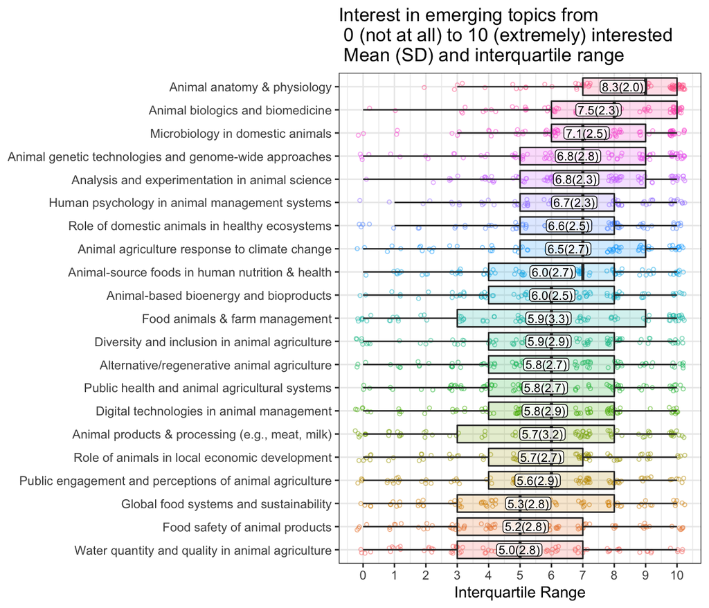

### 4.1.2 Differences by major

Splitting the data into students in Animal Science and Dairy Science (n = 57) vs. students in Other (n = 28) majors illustrates differences in mean topic interest. As expected, AnDySci majors were more interested in many topics such as animal anatomy & physiology, animal genetic technologies and genome-wide approaches, and analysis and experimentation in animal science. Mean topic interest was similar for many “moderate-interest” topics. Several topics were rated as more interesting by non-AnDySci (Other) majors than AnDySci majors. These included: Animal-based bioenergy and bioproducts, alternative agriculture, public health and animal agricultural systems, and global food systems and sustainability.

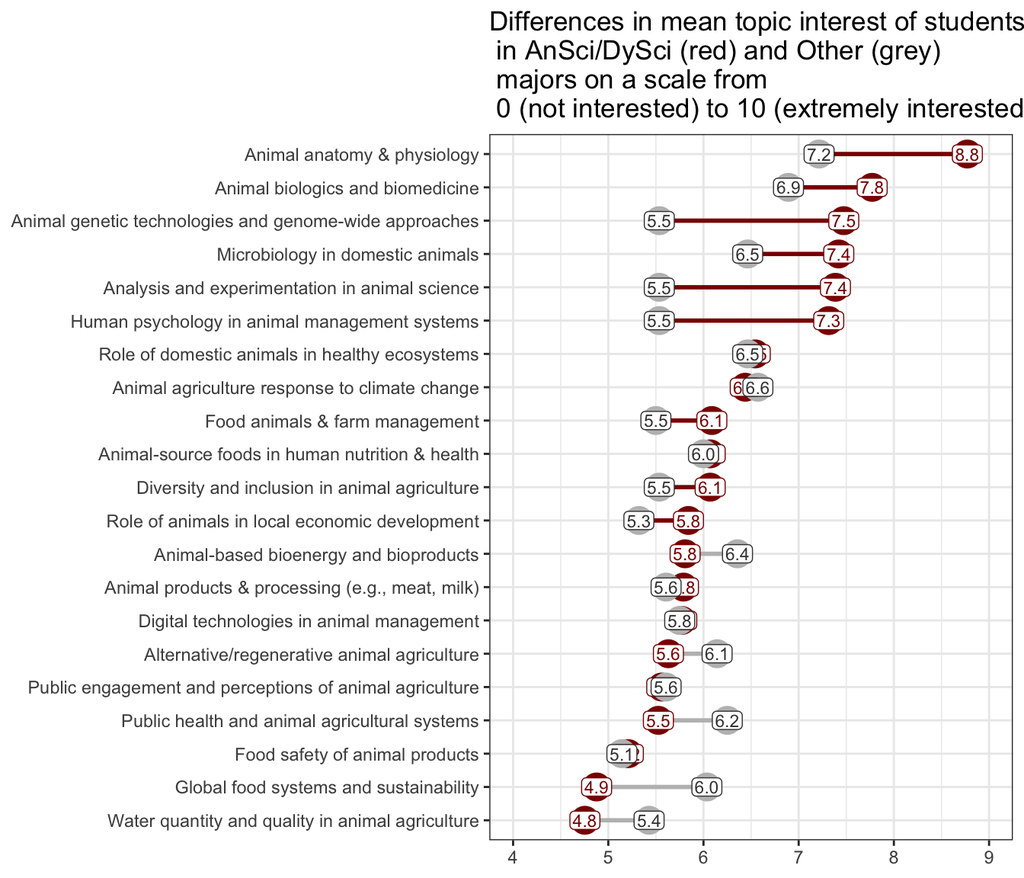

## 4.2 Past Learning Experience

Students reported being extremely experienced with lecture-based learning, and moderately-experienced with hybrid, discipline-based, discussion-based, blended, seminar, and interdisciplinary learning. Students reported having the least experience with flipped classroom and independent study. These results show a bias toward experience with lecture-based study and away from active learning modalities.

### 4.2.1 As continuous - Mean(SD)

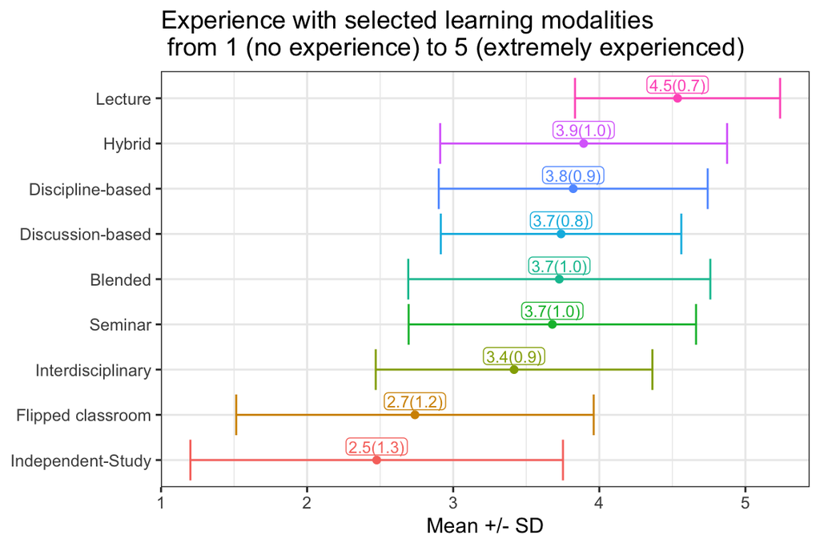

### 4.2.2 As ordinal - Stacked bar

Percentage respondents selecting each rating category

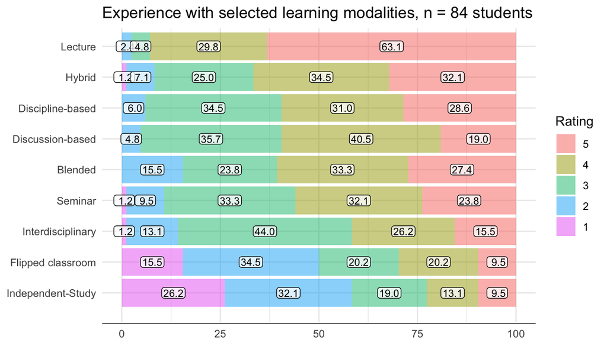

## 4.3 Learning Preferences

### 4.3.1 As continuous - Mean(SD)

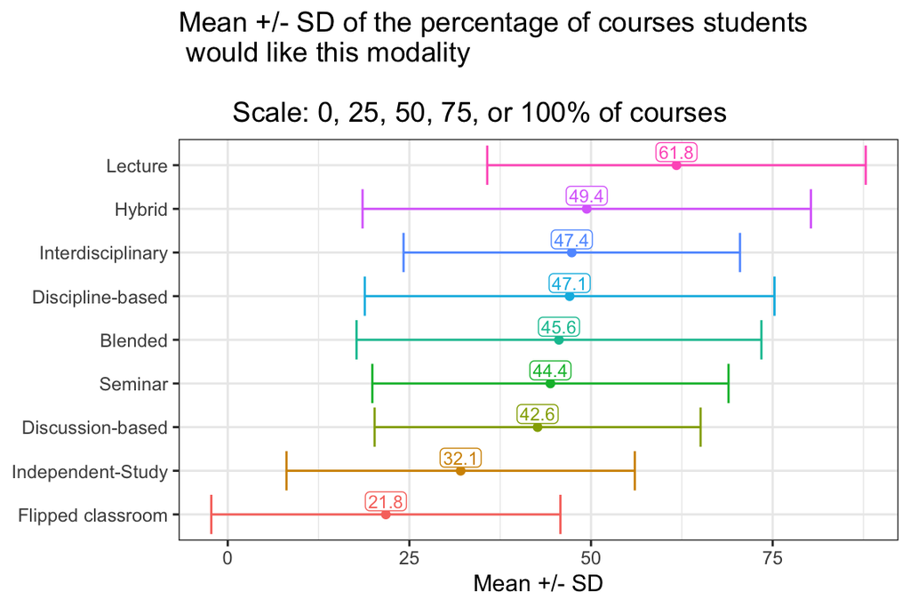

### 4.3.2 As ordinal - Stacked bar

Percentage respondents selecting each rating category.

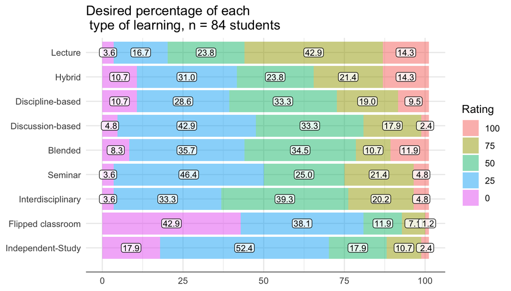